# Dynamik von Gebirgswäldern im Nationalpark Berchtesgaden

# 3 Höhen- und altersabhängige Wuchsdynamik

Ein zentrales Thema der Stelle ist die langfristige Entwicklung unter dem globalen Wandel. Zwei komplementäre Blicke auf die echten Daten:

## 3.1 Wachstum gegen Kambialalter (Alterstrend)

**R-Code anzeigen**

```r
to_age <- function(x) {
  i <- which(!is.na(x)); if (!length(i)) return(rep(NA_real_, length(x)))
  v <- x[min(i):max(i)]; length(v) <- length(x); v
}
age_curve <- imap_dfr(rwl_list, function(rwl, sp) {
  aligned <- apply(as.matrix(rwl), 2, to_age)
  tibble(age = seq_len(nrow(aligned)),
         rw  = rowMeans(aligned, na.rm = TRUE),
         nser = rowSums(!is.na(aligned)),
         Art = sp)
}) |> filter(nser >= 3, age <= 220)
```

**R-Code anzeigen**

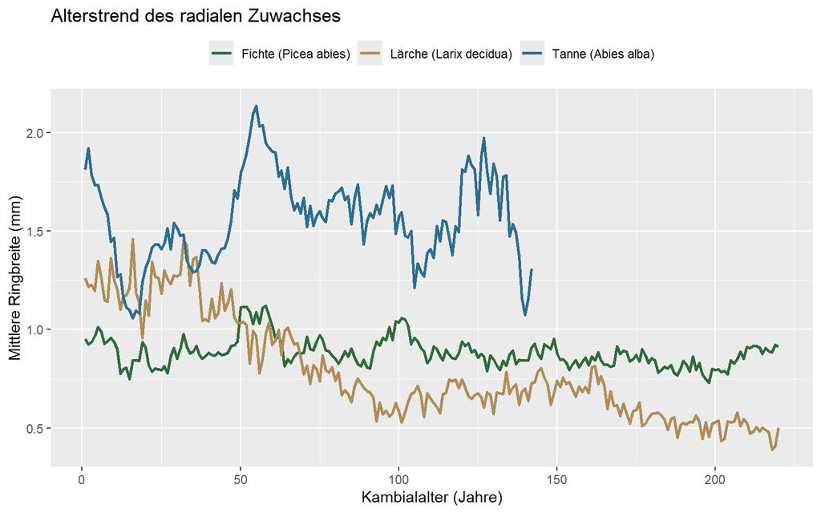

```r
ggplot(age_curve, aes(age, rw, color = Art)) +
  geom_line(linewidth = 1) +
  scale_color_manual(values = sp_cols) +
  labs(title = "Alterstrend des radialen Zuwachses",
       x = "Kambialalter (Jahre)", y = "Mittlere Ringbreite (mm)", color = NULL) +
  theme(legend.position = "top")
```

## 3.2 Jüngerer Wuchstrend (Klimawandel-Signal)

**R-Code anzeigen**

```r
recent <- chrono_df |>
  filter(year >= 1900) |>
  group_by(Art, period = if_else(year >= 1980, "1980–2008", "1900–1979")) |>
  summarise(rwi = mean(rwi, na.rm = TRUE), .groups = "drop")
```

**R-Code anzeigen**

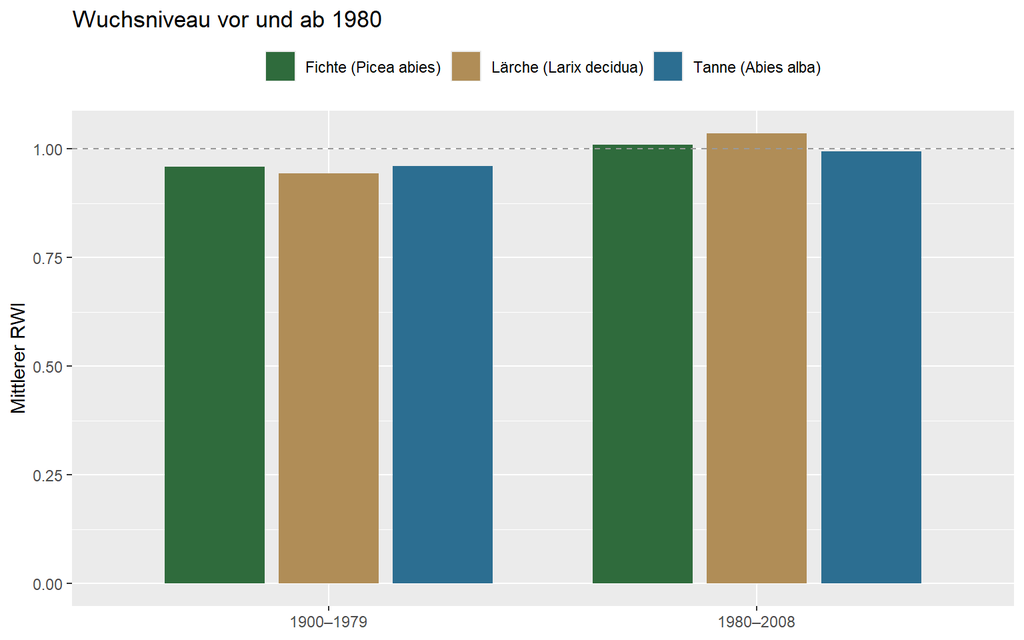

Abbildung 5: Mittlerer RWI vor und ab 1980. Höhenlagen-Kontrast: Aussagen zur Vulnerabilität bzw. Begünstigung der Arten unter Erwärmung lassen sich so empirisch prüfen (vgl. Hartl-Meier et al. 2014).

```r
ggplot(recent, aes(period, rwi, fill = Art)) +
  geom_col(position = position_dodge(0.8), width = 0.7) +
  geom_hline(yintercept = 1, color = "grey60", linetype = 2) +
  scale_fill_manual(values = sp_cols) +
  labs(title = "Wuchsniveau vor und ab 1980", x = NULL, y = "Mittlerer RWI", fill = NULL) +
  theme(legend.position = "top")
```

## 3.3 Negative Weiserjahre

**R-Code anzeigen**

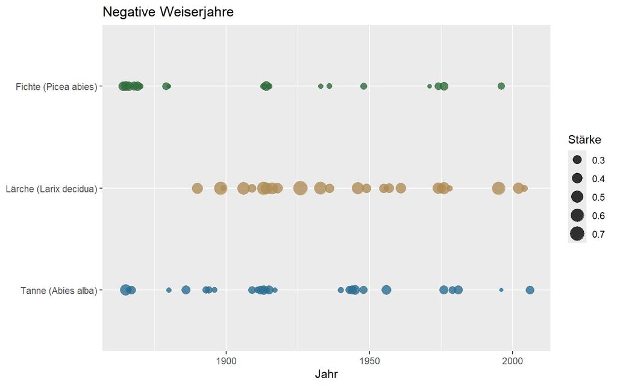

Abbildung 6: Jahre mit stark unterdurchschnittlichem Wachstum (RWI < 0,8) je Art. Häufungen fallen mit bekannten Extremjahren der Alpen zusammen (u. a. 1976 Trockenheit, 1948, 1962).

```r
pointer <- chrono_df |> filter(rwi < 0.8, year >= 1850)
ggplot(pointer, aes(year, fct_rev(factor(Art)), color = Art, size = 1 - rwi)) +
  geom_point(alpha = 0.8) +
  scale_color_manual(values = sp_cols, guide = "none") +
  scale_size_continuous(range = c(1.5, 6), name = "Stärke") +
  labs(title = "Negative Weiserjahre", x = "Jahr", y = NULL)
```

# 4 Feldarbeitsplanung (Entwurf)

Dieser Abschnitt ist ein **methodischer Entwurf** für die Stichprobenplanung des Projekts. Die Stichprobenumfänge sind aber nicht beliebig gewählt, sondern aus den oben aus echten Daten geschätzten Kennwerten (Interserien-Korrelation, Effektgrößen) abgeleitet.

## 4.1 Geschichtetes Stichprobendesign

Vorschlag: stratifizierte Zufallsstichprobe über den Höhengradienten (montan, hochmontan, subalpin) × Exposition (Nord/Süd). Die Allokation folgt der Fläche der Straten (proportional), mit Mindestbesatz je Stratum.

**R-Code anzeigen**

```r
strata <- expand_grid(
  Stufe   = factor(c("montan", "hochmontan", "subalpin"),
                   levels = c("montan", "hochmontan", "subalpin")),
  Exposition = c("Nord", "Süd")) |>
  mutate(
    flaeche_km2 = c(34, 30, 22, 26, 18, 20),     # angenommene Stratenflächen
    plots = pmax(6, round(flaeche_km2 / sum(flaeche_km2) * 60))  # ~60 Plots gesamt
  )
```

**R-Code anzeigen**

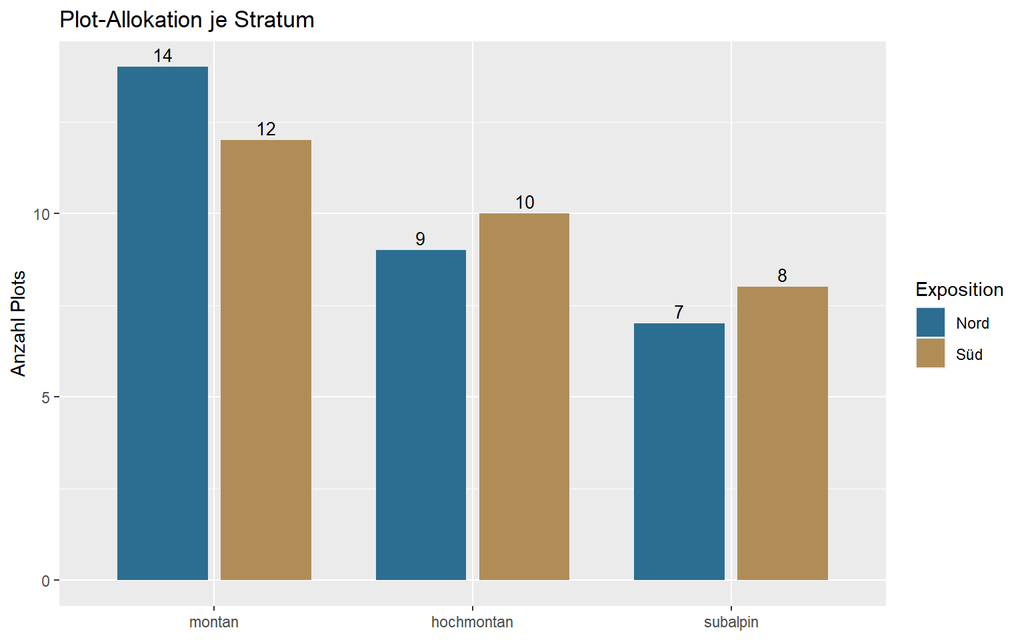

Abbildung 7: Vorgeschlagene proportionale Allokation der Inventur-/Bohrplots auf die Straten (Höhenstufe × Exposition). Gesamtumfang hier rund 60 Plots.

```r
ggplot(strata, aes(Stufe, plots, fill = Exposition)) +
  geom_col(position = position_dodge(0.8), width = 0.7) +
  geom_text(aes(label = plots), position = position_dodge(0.8), vjust = -0.4, size = 3.5) +
  scale_fill_manual(values = c(Nord = col_ta, Süd = col_la)) +
  labs(title = "Plot-Allokation je Stratum", x = NULL, y = "Anzahl Plots")
```

## 4.2 Stichprobenumfang I — Chronologie (EPS)

Wie viele Bäume braucht es pro Standort für eine belastbare Chronologie? Das EPS hängt über $\mathrm{EPS}(n) = \dfrac{n\,\bar r}{1+(n-1)\,\bar r}$ von der Baumzahl $n$ und der mittleren Interserien-Korrelation $\bar r$ ab. Hier mit den **echten $\bar r$-Werten** der drei Standorte.

**R-Code anzeigen**

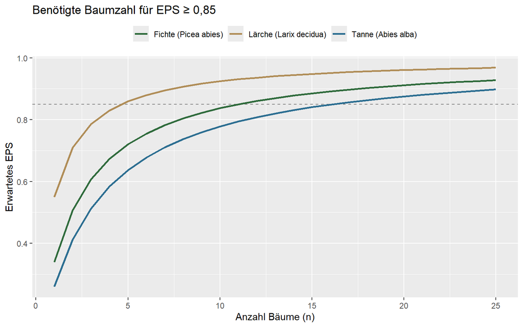

Abbildung 8: Erwartetes EPS gegen die Baumzahl, basierend auf den real geschätzten Interserien-Korrelationen je Art. Gestrichelt: Schwellenwert 0,85. Ablesbar, wie viele Bäume pro Standort genügen.

```r
rbar_obs <- site_summary |> transmute(Art, rbar = rbar)
eps_df <- rbar_obs |>
  crossing(n = 1:25) |>
  mutate(eps = n * rbar / (1 + (n - 1) * rbar))
n_needed <- eps_df |> filter(eps >= 0.85) |> group_by(Art) |> summarise(n_min = min(n))

ggplot(eps_df, aes(n, eps, color = Art)) +
  geom_hline(yintercept = 0.85, linetype = 2, color = "grey50") +
  geom_line(linewidth = 1) +
  scale_color_manual(values = sp_cols) +
  labs(title = "Benötigte Baumzahl für EPS ≥ 0,85",
       x = "Anzahl Bäume (n)", y = "Erwartetes EPS", color = NULL) +
  theme(legend.position = "top")
```

Bei den hohen realen Korrelationen genügen je nach Art bereits 5–17 Bäume pro Standort, um den Schwellenwert EPS ≥ 0,85 zu erreichen — ein direkt verwertbarer Planungswert.

## 4.3 Stichprobenumfang II — Verjüngungsexperiment (Power)

Für das Freilandexperiment zur verkürzten Schneedeckendauer: Wie viele Keimlinge pro Behandlung sind nötig, um einen Rückgang der Überlebensrate zu erkennen? Klassische Power-Analyse für den Vergleich zweier Anteile (Basis-Überleben 55 %).

**R-Code anzeigen**

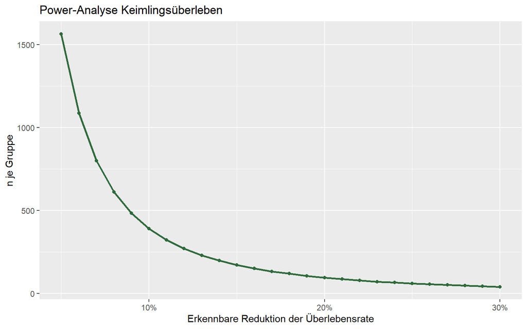

Abbildung 9: Benötigter Stichprobenumfang je Behandlungsgruppe (Power 0,8; α = 0,05) gegen die zu erkennende absolute Reduktion der Überlebensrate gegenüber 55 % Kontrolle.

```r
p0 <- 0.55
effects <- seq(0.05, 0.30, by = 0.01)
pw <- tibble(delta = effects,
             n = map_dbl(effects, ~ ceiling(
               power.prop.test(p1 = p0, p2 = p0 - .x,
                               power = 0.8, sig.level = 0.05)$n)))

ggplot(pw, aes(delta, n)) +
  geom_line(color = col_fi, linewidth = 1) +
  geom_point(color = col_fi) +
  scale_x_continuous(labels = percent_format()) +
  labs(title = "Power-Analyse Keimlingsüberleben",
       x = "Erkennbare Reduktion der Überlebensrate", y = "n je Gruppe")
```

**R-Code anzeigen**

```r
n_med <- ceiling(power.prop.test(p1 = p0, p2 = p0 - 0.15,
                                 power = 0.8, sig.level = 0.05)$n)
```

Um einen Rückgang von 15 Prozentpunkten (55 % → 40 %) zu erkennen, sind rund **173 Keimlinge pro Behandlung** nötig — bei drei Behandlungen und z. B. 8 Blöcken ein konkret planbarer Erhebungsumfang.

## 4.4 Aufwand & Kampagnenplan

**R-Code anzeigen**

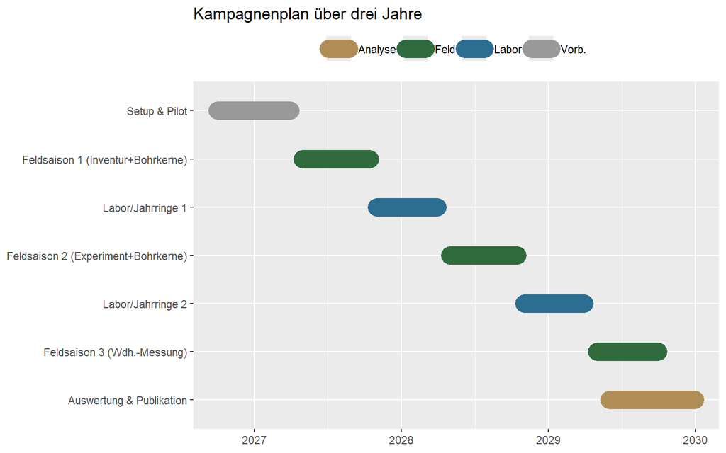

Abbildung 10: Grobplanung des dreijährigen Projekts: Feldsaisons (Sommer), Labor-/Jahrringarbeit (Winter) und Auswertung/Publikation. Feldarbeit im physisch anspruchsvollen Gelände konzentriert auf die schneefreien Monate.

```r
phasen <- tribble(
  ~Phase,                         ~Start,       ~Ende,        ~Typ,
  "Setup & Pilot",                "2026-10-01", "2027-03-31", "Vorb.",
  "Feldsaison 1 (Inventur+Bohrkerne)", "2027-05-01", "2027-10-15", "Feld",
  "Labor/Jahrringe 1",            "2027-11-01", "2028-03-31", "Labor",
  "Feldsaison 2 (Experiment+Bohrkerne)", "2028-05-01", "2028-10-15", "Feld",
  "Labor/Jahrringe 2",            "2028-11-01", "2029-03-31", "Labor",
  "Feldsaison 3 (Wdh.-Messung)",  "2029-05-01", "2029-09-30", "Feld",
  "Auswertung & Publikation",     "2029-06-01", "2029-12-31", "Analyse"
) |>
  mutate(across(c(Start, Ende), as.Date),
         Phase = factor(Phase, levels = rev(Phase)))

ggplot(phasen, aes(y = Phase)) +
  geom_segment(aes(x = Start, xend = Ende, yend = Phase, color = Typ),
               linewidth = 7, lineend = "round") +
  scale_color_manual(values = c(Vorb. = "grey60", Feld = col_fi,
                                Labor = col_ta, Analyse = col_la)) +
  labs(title = "Kampagnenplan über drei Jahre", x = NULL, y = NULL, color = NULL) +
  theme(legend.position = "top")
```

**R-Code anzeigen**

```r
effort <- tibble(
  Posten = c("Inventurplots", "Bohrkerne (2/Baum)", "Keimlinge im Experiment",
             "Feldtage gesamt", "Bohrkerne pro Feldtag"),
  Wert = c(sum(strata$plots),
           sum(strata$plots) * 15 * 2,
           n_med * 3 * 8,
           round(sum(strata$plots) / 4 + 30),
           "≈ 25–35"))
DT::datatable(effort, options = list(dom = "t"),
  caption = "Tabelle 3: Abgeleiteter Erhebungsaufwand aus Design und Stichprobenrechnung.")
```

|  | Posten | Wert |
| --- | --- | --- |
| 1 | Inventurplots | 60 |
| 2 | Bohrkerne (2/Baum) | 1800 |
| 3 | Keimlinge im Experiment | 4152 |
| 4 | Feldtage gesamt | 45 |
| 5 | Bohrkerne pro Feldtag | ≈ 25–35 |

# 5 Bezug zur Stelle

| Anforderung der Ausschreibung | In diesem Dokument |
| --- | --- |
| Dendro-ökologische Daten erheben & bearbeiten | Echte ITRDB-Daten, Detrending, Chronologie, EPS/rbar, Weiserjahre |
| Programmierkenntnisse (R) | Durchgängiger, reproduzierbarer `dplR`/`tidyverse`-Workflow |
| Räumliche Analysen (GIS) | Höhengradient, Standortkarte, stratifiziertes Design |
| Statistische Analysen | Regionalkurve, Korrelationen, Power-/EPS-Stichprobenrechnung |
| Planung von Feldarbeiten im anspruchsvollen Gelände | Geschichtetes Design, Stichprobenumfang, Kampagnen-/Aufwandsplan |
| Walddynamik & globaler Wandel | Alters- und Höhentrends, jüngeres Wuchssignal, Schneedecken-Experiment |
| Wissenschaftskommunikation | Dieses reproduzierbare, selbsterklärende HTML-Dokument |

# Datenquellen & Reproduzierbarkeit

Tucson-Ringbreitendaten, International Tree-Ring Data Bank (ITRDB) / NOAA NCEI Paleoclimatology, erhoben von **Hartl-Meier, C., Dittmar, C., Zang, C., Rothe, A.**:

- Fichte (*Picea abies*), Sittersbach, 1600 m — ITRDB **DEU364**
- Tanne (*Abies alba*), Ochshütte, 770 m — ITRDB **DEU334**
- Lärche (*Larix decidua*), Sittersbach, 1600 m — ITRDB **DEU365**

Zugehörige Publikationen: Hartl-Meier et al. (2014), *Vulnerability of Norway spruce to climate change in mountain forests of the European Alps*, Clim. Res. (doi:10.3354/cr01226); und *Mountain forest growth response to climate change in the Northern Limestone Alps*, Trees (doi:10.1007/s00468-014-0994-1).